# Machine Learning and Predicting Exercise Movements

Wes Sauder

Monday, July 17

### Synopsis:

Using devices such as Jawbone Up, Nike FuelBand, and Fitbit it is now possible to collect a large amount of data about personal activity relatively inexpensively. These type of devices are part of the quantified self movement, a group of enthusiasts who take measurements about themselves regularly to improve their health, to find patterns in their behavior, or because they are tech geeks. One thing that people regularly do is quantify how much of a particular activity they do, but they rarely quantify how well they do it. In this project, your goal will be to use data from accelerometers on the belt, forearm, arm, and dumbell of 6 participants. They were asked to perform barbell lifts correctly and incorrectly in 5 different ways. More information is available from the website here: http://groupware.les.inf.puc-rio.br/har (see the section on the Weight Lifting Exercise Dataset).

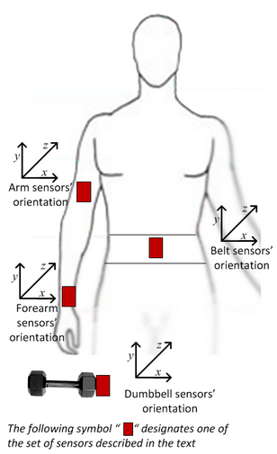

Data was accumulated using sensors in various positions -

- Class A: Proper Lift - according to the specification
- Class B: Improprer Lift - elbows to the front
- Class C: Improprer Lift - lifting the dumbbell only halfway
- Class D: Improprer Lift - lowering the dumbbell only halfway
- Class E: Improprer Lift - hips to the front

**PLEASE NOTE: Some Code can be viewed in the APPENDIX of this study to streamline the presentation**

```r
set.seed(12345)
rm(list = ls(all = TRUE))  #Clear Global Environment
library(ggplot2)  #Packages
library(caret)
library(dplyr)
library(randomForest)

setwd("C:/Users/WSauder/Documents/R Work")

trainFileName <- "pml-training.csv"
testFileName <- "pml-testing.csv"

trainingOrig <- read.csv(trainFileName, na.strings = c("", "NA"))
testingOrig <- read.csv(testFileName, na.strings = c("", "NA"))
trainingOrig$classe <- as.factor(trainingOrig$classe)  #Make the classe variable a factor
```

#### **Results of Exploratory Study and Variable Readiness**

The size of the initial study is substantial. The current dimensions are (Rows, Columns):

```
[1] 19622   160
```

Therefore, it is important to clear columns without value when constructing the model. Starting with removing ‘NA’ or columns with no data and other columns with inconsistent or unreliable data including: X, user_name and cvtd_timestamp

```r
# Prep TRAINING
redTrain <- trainingOrig[, colSums(is.na(trainingOrig)) == 0]  # Remove unpopulated columns (IE = NA)
redTrain <- redTrain[, 8:60]  # Remove leading columns which are unreliable and/or provide no value to ML
# Prep TESTING using the same constraints
redTest <- testingOrig[, colSums(is.na(testingOrig)) == 0]  # Remove unpopulated columns (IE = NA)
redTest <- redTest[, 8:60]  # Remove leading columns which are unreliable and/or provide no value to ML
```

```r
nonNumCols <- which(lapply(redTrain, class) %in% "numeric")  # Training and Validation Data First
trained <- redTrain[nonNumCols]
trained$classe = redTrain$classe
testData <- redTest[nonNumCols]  #Remove Columns from Test Data
testData <- data.frame(sapply(testData, as.numeric))  # Convert Integer variables to Numeric  #ensure rest of columns are converted to Numeric
```

#### Removing the near zero variables

Ensure no other variables could be removed using values near zero. None were found.

```r
nearZeroVariables <- nearZeroVar(trained, saveMetrics = TRUE)
nearZeroVariables
```

```
##                   freqRatio percentUnique zeroVar   nzv
## roll_belt          1.101904     6.7781062   FALSE FALSE
## pitch_belt         1.036082     9.3772296   FALSE FALSE
## yaw_belt           1.058480     9.9734991   FALSE FALSE
## gyros_belt_x       1.058651     0.7134849   FALSE FALSE
## gyros_belt_y       1.144000     0.3516461   FALSE FALSE
## gyros_belt_z       1.066214     0.8612782   FALSE FALSE
## roll_arm          52.338462    13.5256345   FALSE FALSE
## pitch_arm         87.256410    15.7323412   FALSE FALSE
## yaw_arm           33.029126    14.6570176   FALSE FALSE
## gyros_arm_x        1.015504     3.2769341   FALSE FALSE
## gyros_arm_y        1.454369     1.9162165   FALSE FALSE
## gyros_arm_z        1.110687     1.2638875   FALSE FALSE
## roll_dumbbell      1.022388    84.2065029   FALSE FALSE
## pitch_dumbbell     2.277372    81.7449801   FALSE FALSE
## yaw_dumbbell       1.132231    83.4828254   FALSE FALSE
## gyros_dumbbell_x   1.003268     1.2282132   FALSE FALSE
## gyros_dumbbell_y   1.264957     1.4167771   FALSE FALSE
## gyros_dumbbell_z   1.060100     1.0498420   FALSE FALSE
## magnet_dumbbell_z  1.020833     3.4451126   FALSE FALSE
## roll_forearm      11.589286    11.0895933   FALSE FALSE
## pitch_forearm     65.983051    14.8557741   FALSE FALSE
## yaw_forearm       15.322835    10.1467740   FALSE FALSE
## gyros_forearm_x    1.059273     1.5187035   FALSE FALSE
## gyros_forearm_y    1.036554     3.7763735   FALSE FALSE
## gyros_forearm_z    1.122917     1.5645704   FALSE FALSE
## magnet_forearm_y   1.246914     9.5403119   FALSE FALSE
## magnet_forearm_z   1.000000     8.5771073   FALSE FALSE
## classe             1.469581     0.0254816   FALSE FALSE
```

#### Create cross validation set

The training set is divided in two parts, one for training and the other for cross validation

```r
trained$classe = redTrain$classe            # Push Classe Back to the dataset.
inTrain = createDataPartition(trained$classe, p = .8, list=FALSE)
training = trained[inTrain,]
CVdata = trained[-inTrain,]
```

After the final column purge, the dimensions of the Original, Training, Validation and Testing sets respectively are (Rows, Columns):

```
[1] 19622   160
```

```
[1] 15699    28
```

```
[1] 3923   28
```

```
[1] 20 27
```

#### Train model

```r
RF_model <- train(classe ~.,
                  method="rf",
                  data=training,
                  prof = TRUE,
                  trControl=trainControl(method='cv'),
                  number=4,
                  allowParallel=TRUE )
```

#### Accuracy on training set and cross validation set

Following the computation on the accuracy of trainig and cross validation set

Ensure Model is correct by running Test Data against the trained object. Training set:

```r
trainingPred <- predict(RF_model, training[,0:27])
confusionMatrix(trainingPred, training$classe)
```

```
## Confusion Matrix and Statistics
##
##           Reference
## Prediction    A    B    C    D    E
##          A 4464    0    0    0    0
##          B    0 3038    0    0    0
##          C    0    0 2738    0    0
##          D    0    0    0 2573    0
##          E    0    0    0    0 2886
##
## Overall Statistics
##
##                Accuracy : 1
##                  95% CI : (0.9998, 1)
##     No Information Rate : 0.2843
##     P-Value [Acc > NIR] : < 2.2e-16
##
##                   Kappa : 1
##  Mcnemar's Test P-Value : NA
##
## Statistics by Class:
##
##                      Class: A Class: B Class: C Class: D Class: E
## Sensitivity            1.0000   1.0000   1.0000   1.0000   1.0000
## Specificity            1.0000   1.0000   1.0000   1.0000   1.0000
## Pos Pred Value         1.0000   1.0000   1.0000   1.0000   1.0000
## Neg Pred Value         1.0000   1.0000   1.0000   1.0000   1.0000
## Prevalence             0.2843   0.1935   0.1744   0.1639   0.1838
## Detection Rate         0.2843   0.1935   0.1744   0.1639   0.1838
## Detection Prevalence   0.2843   0.1935   0.1744   0.1639   0.1838
## Balanced Accuracy      1.0000   1.0000   1.0000   1.0000   1.0000
```

#### Cross validation Results

```r
PredictedCV_Val <- predict(RF_model, CVdata[,0:27])
confusionMatrix(PredictedCV_Val, CVdata$classe)
```

```
## Confusion Matrix and Statistics
##
##           Reference
## Prediction    A    B    C    D    E
##          A 1115    7    0    0    2
##          B    1  750    3    0    0
##          C    0    2  676    7    1
##          D    0    0    5  635    0
##          E    0    0    0    1  718
##
## Overall Statistics
##
##                Accuracy : 0.9926
##                  95% CI : (0.9894, 0.995)
##     No Information Rate : 0.2845
##     P-Value [Acc > NIR] : < 2.2e-16
##
##                   Kappa : 0.9906
##  Mcnemar's Test P-Value : NA
##
## Statistics by Class:
##
##                      Class: A Class: B Class: C Class: D Class: E
## Sensitivity            0.9991   0.9881   0.9883   0.9876   0.9958
## Specificity            0.9968   0.9987   0.9969   0.9985   0.9997
## Pos Pred Value         0.9920   0.9947   0.9854   0.9922   0.9986
## Neg Pred Value         0.9996   0.9972   0.9975   0.9976   0.9991
## Prevalence             0.2845   0.1935   0.1744   0.1639   0.1838
## Detection Rate         0.2842   0.1912   0.1723   0.1619   0.1830
## Detection Prevalence   0.2865   0.1922   0.1749   0.1631   0.1833
## Balanced Accuracy      0.9979   0.9934   0.9926   0.9930   0.9978
```

#### Predicting using TEST Data

Predictions on the real testing set provided in the exercise

```r
TestRF_Output <- predict(RF_model,redTest )
TestRF_Output
```

```
##  [1] B A B A A E D B A A B C B A E E A B B B
## Levels: A B C D E
```

### APPENDIX - R Code Used in Study

#### **Final Clean Up - File Creation for Grading and Model Caching**

Save the Results For Grading

```r
pml_write_files = function(x) {
    n = length(x)
    for (i in 1:n) {
        filename = paste0("problem_id_", i, ".txt")
        write.table(x[i], file = filename, quote = FALSE, row.names = FALSE,
            col.names = FALSE)
    }
}
pml_write_files(TestRF_Output)  #Use the Working Directory in in the initial setup.

# saveRDS(RF_model, file='RandomForestsModel.rds')
```